# Purpose

This method takes a proteins with abundance and disorder scores, and places the proteins into bins according to those scores.

It returns a list of data frames. Each one of those data frames corresponds to an “abundance X disorder bin”. The data frames contain rows of Proteins. The proteins have been placed into their respective abundance X disorder bins based on their abundance and disorder data.

# Function Documentation

All functions for this method can be found in:

’scripts/binning_functions.R”

# Method Walkthrough

To outline the method, we will be binning the yeast genome into a 5x5 matrix according to their abundance and disorder scores

## 1.Setup

Run setup files and access functions

```r
library(tidyverse)
```

```r
library(ggplot2)
library(knitr)
source('scripts/binning_functions.R')
```

## 2. Open Yeast Protein Data

Open a dataframe of yeast protein data.

**master**: Dataframe containing yeast protein data

The columns that are relevant to this method are as follows:

**uniprot_id** : The uniprot id of a protein (str)

**disopred3perc** : The percent of a protein amino acid residues that are predicted to be disordered according to Disopred3 (float)

**abundance** : The abundance of a protein according to Paxdb (float). See Methods for more info on data source

**OE** : Value is 1 if the protein displays an overexpression phenotype, otherwise the value is NA. These yeast genes were overexpressed with a viral promoter, they are the Sapko yeast lines. See Methods for more info on data source

**new_oe** : Value is 1 if the protein displays an overexpression phenotype, otherwise the value is NA. These yeast genes were overexpressed with the endogenous promoter. They are the Morrill yeast lines.

```r
master <- read.delim(file = 'data/merged_tables/yeast/actual_master.tsv',
                     sep = "\t")

print(paste('Size of Master Data Frame: ', nrow(master)))
```

```
## [1] "Size of Master Data Frame:  6730"
```

| uniprot_id | disopred3perc | iupredperc | abundance | uniprot_symbols | entrez_id | HI | OE | new_oe | drlps_drivers | drpls_clients | dr_all_phase_sep |
| --- | --- | --- | --- | --- | --- | --- | --- | --- | --- | --- | --- |
| P53068 | 21.60 | 2.80 | 11.3 | DOC1 APC10 YGL240W HRC283 | NA | NA | NA | NA | NA | NA | NA |
| Q01846 | 35.13 | 6.47 | 7.3 | MDM1 YML104C YM8339.15C | NA | NA | NA | NA | NA | NA | NA |
| P40084 | 23.00 | 7.07 | 53.9 | RTR1 YER139C | NA | NA | NA | NA | NA | NA | NA |
| P39708 | 0.21 | 0.87 | 15.0 | GDH3 YAL062W FUN51 | NA | NA | NA | NA | NA | NA | NA |
| P23542 | 0.71 | 0.00 | 392.0 | AAT2 ASP5 YLR027C L1746 | NA | NA | NA | NA | NA | NA | NA |

## 3. Setting Global Parameters

Identify how many stratifications of proteome you desire.

**For example:**

You could choose to split the proteome into 4 abundance bins, and 4 disorder bins. Or you could choose to split the proteome into 5 abundance bins and 3 disorder bins.

**abundance_groups** :The number of abundance groups to split the proteome into

**disorder_groups** : The number of disorder groups to split the proteome into

**abundance_col** : The name of the column which contains abundance information

**disorder_col** : The name of the column which contains disorder information

```r
abundance_groups <-  5
disorder_groups <-  5
disorder_col <-  'disopred3perc'
abundance_col <-  'abundance'
```

## 4. Preliminary Filtering

Perform some preliminary filtering of the yeast master data frame

1. log2+1 transform abundance scores
2. Remove proteins that lack abundance OR disorder scores

```r
master$abundance <- log2(master$abundance+1)

master <- filter(master,
                 !is.na(!!sym(abundance_col)) & !is.na(!!sym(disorder_col)))
print(paste('Size of Master Data Frame: ', nrow(master)))
```

```
## [1] "Size of Master Data Frame:  5939"
```

| uniprot_id | disopred3perc | iupredperc | abundance | uniprot_symbols | entrez_id | HI | OE | new_oe | drlps_drivers | drpls_clients | dr_all_phase_sep |
| --- | --- | --- | --- | --- | --- | --- | --- | --- | --- | --- | --- |
| Q04689 | 14.46 | 7.39 | 1.292782 | AIM32 YML050W YM9827.02 | NA | NA | NA | NA | NA | NA | NA |
| P42884 | 6.91 | 4.25 | 1.275007 | AAD14 YNL331C N0300 | NA | NA | NA | NA | NA | NA | NA |
| P21595 | 8.17 | 1.02 | 1.700440 | DIT2 CYP56 YDR402C D9509.20 | NA | NA | NA | NA | NA | NA | NA |
| P47146 | 0.81 | 0.00 | 1.372952 | ABM1 YJR108W J1988 | NA | NA | NA | NA | NA | NA | NA |
| Q12239 | 17.54 | 0.00 | 4.070389 | YOL107W | NA | NA | NA | NA | NA | NA | NA |

## 5. Create Abundance and Disorder bins using create_bins()

create_bins() is a wrapper function which returns a list of lists. Each list is an abundance X disorder bin.

For full documentation, please see ’scripts/binning_functions.R”

The steps of how create_abundance works is broken down below…

### 5.1.1 Identify bounds for the Abundance bin

Given how many abundance bins we desire and the number of rows in master, get_bounds returns the indexes where we need to split the master data frame

```r
abundance_bounds <- get_bounds(master, group_col = abundance_col, group_size = abundance_groups)
abundance_bounds
```

```
## [1]    1 1188 2376 3564 4752 5939
```

### 5.1.2 Add Abundance Bin information

add_bin_info() is a wrapper for several simple steps.

The added column, “abundance_bin”, denotes what abundance bin a protein is in. Higher values indicate that the protein is in a bin with higher abundance.

```r
master <- add_bin_info(master,
                       bounds = abundance_bounds,
                       bounds_column = abundance_col,
                       newcolname = 'abundance_bin')
kable(sample_n(master, size = 5))
```

| uniprot_id | disopred3perc | iupredperc | abundance | uniprot_symbols | entrez_id | HI | OE | new_oe | drlps_drivers | drpls_clients | dr_all_phase_sep | abundance_bin |
| --- | --- | --- | --- | --- | --- | --- | --- | --- | --- | --- | --- | --- |
| Q08754 | 16.35 | 4.28 | 4.357552 | BUD7 YOR299W | NA | NA | NA | NA | NA | NA | NA | 3 |
| P38182 | 0.00 | 0.00 | 4.517276 | ATG8 APG8 AUT7 CVT5 YBL078C YBL0732 | NA | NA | NA | NA | NA | NA | 1 | 3 |
| P53688 | 8.91 | 11.62 | 2.488001 | HST4 YDR191W YD9346.03 | NA | NA | NA | NA | NA | NA | NA | 2 |
| P47035 | 92.01 | 85.95 | 5.887525 | NET1 CFI1 ESC5 SRM8 YJL076W J1038 | NA | NA | NA | NA | NA | NA | NA | 4 |
| Q02732 | 16.26 | 17.34 | 3.963474 | CTF19 MCM18 YPL018W LPB13W | NA | NA | NA | NA | NA | NA | NA | 3 |

### 5.1.3 Perform steps 5.1.1 - 5.1.2 for Disorder

The added column, “disorder_bin”, denotes what disorder bin a protein is in. Higher values indicate that the protein is in a bin with higher disorder.

```r
disorder_bounds <- get_bounds(master, group_col = disorder_col, group_size = disorder_groups)
disorder_bounds
```

```
## [1]    1 1188 2376 3564 4752 5939
```

```r
master <- add_bin_info(master,
                    bounds = disorder_bounds,
                    bounds_column = disorder_col,
                    newcolname = 'disorder_bin')
kable(sample_n(master, size = 5))
```

| uniprot_id | disopred3perc | iupredperc | abundance | uniprot_symbols | entrez_id | HI | OE | new_oe | drlps_drivers | drpls_clients | dr_all_phase_sep | abundance_bin | disorder_bin |
| --- | --- | --- | --- | --- | --- | --- | --- | --- | --- | --- | --- | --- | --- |
| P10659 | 0.52 | 2.87 | 11.115044 | SAM1 ETH10 YLR180W L9470.9 | NA | NA | NA | NA | NA | 1 | 1 | 5 | 1 |
| Q02100 | 86.70 | 80.98 | 3.643856 | SKO1 ACR1 YNL167C N1702 | NA | NA | NA | NA | NA | NA | NA | 2 | 5 |
| P42938 | 0.68 | 0.68 | 5.539159 | TDA10 YGR205W G7737 | NA | NA | NA | NA | NA | NA | NA | 4 | 1 |
| P48837 | 60.25 | 59.70 | 7.098032 | NUP57 YGR119C G6320 | NA | NA | NA | NA | NA | NA | NA | 5 | 5 |
| Q02796 | 73.19 | 78.61 | 4.678072 | LGE1 YPL055C | NA | NA | NA | NA | NA | NA | NA | 3 | 5 |

### 5.1.4 Create a List of empty DataFrames

Create A List which contains disorder_groups * abundance_groups amounts of empty DataFrames. The empty DataFrames are where proteins will be placed in accordance with their disorder and abundance bins

The empty DataFrames are named according to the following convention: (AbundanceBinNumber, DisorderBinNumber)

**For example:**

A bin of the name (2,3) will be filled with proteins in the 2nd abundance bin, and the 3rd disorder bin.

A bin of the name (5,3) will be filled with proteins in the 5th abundance bin, and 3rd disorder bin.

```r
list_of_bins <- create_list(abundance_groups, disorder_groups)
list_of_bins
```

```
## 1,1 1,2 1,3 1,4 1,5 2,1 2,2 2,3 2,4 2,5 3,1 3,2 3,3 3,4 3,5 4,1 4,2 4,3 4,4 4,5
##  NA  NA  NA  NA  NA  NA  NA  NA  NA  NA  NA  NA  NA  NA  NA  NA  NA  NA  NA  NA
## 5,1 5,2 5,3 5,4 5,5
##  NA  NA  NA  NA  NA
```

### 5.1.5 Place proteins into their propper bins

All proteins contain information about their abundance and disorder bin.

They are sorted into their respective lists in list_of_bins.

Note: This function takes time…

```r
binned_genes <- place_rows_in_bins(master, list_of_bins, 'abundance_bin', 'disorder_bin')
```

# Summary Statistics of Binned Genes

With the formation of binned_genes, the proteome has now been split into the desired amount of abundance and disorder groups.

This section seeks to give insight into these bins

## The Number of Genes in Each Disorder X Abundance bin

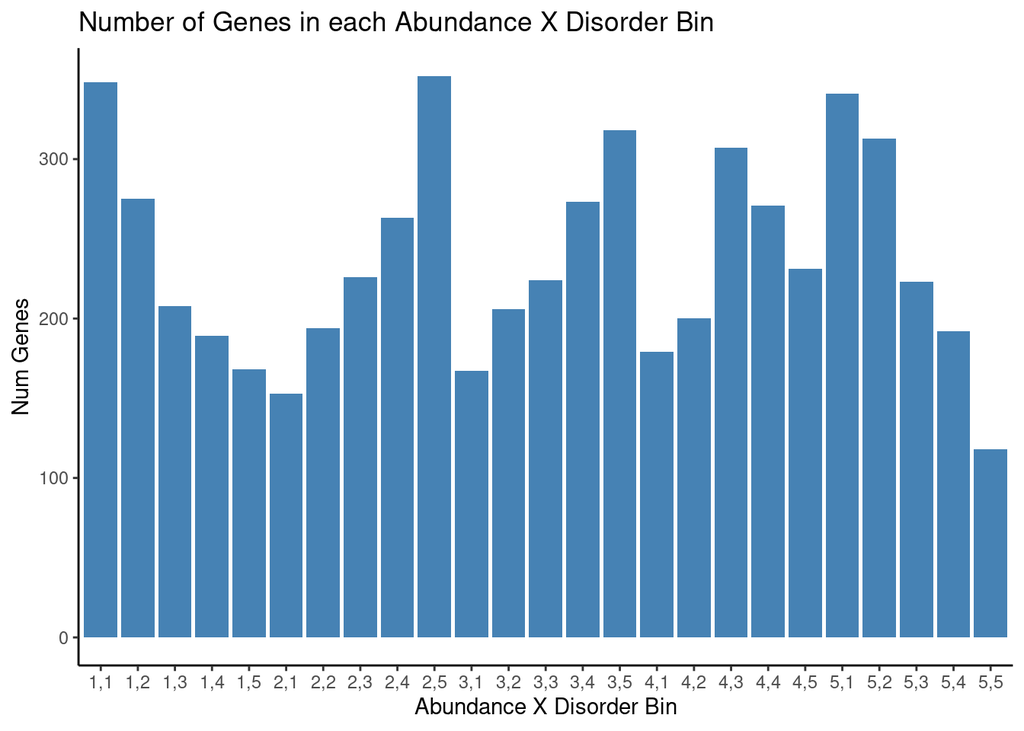

```r
bin_sizes <- lapply(binned_genes, nrow)
bins <- names(bin_sizes)
bin_sizes_df <- data.frame(bs = unlist(bin_sizes),
                           name= bins)
ggplot(bin_sizes_df) +
        geom_col(mapping = aes(x = name, y = bs), fill ='steelblue') +
        labs(title = 'Number of Genes in each Abundance X Disorder Bin') +
        xlab('Abundance X Disorder Bin') +
        ylab( 'Num Genes') +
        theme_classic()
```

### A look into the bin with the lowest abundance and lowest disorder

Lets take a look at the proteins with the lowest abundance and disorder

```r
low_bin <- binned_genes[[1]]
kable(sample_n(low_bin, size = 5))
```

| uniprot_id | disopred3perc | iupredperc | abundance | uniprot_symbols | entrez_id | HI | OE | new_oe | drlps_drivers | drpls_clients | dr_all_phase_sep | abundance_bin | disorder_bin |
| --- | --- | --- | --- | --- | --- | --- | --- | --- | --- | --- | --- | --- | --- |
| P41835 | 0.92 | 2.03 | 1.594548 | THI6 YPL214C | NA | NA | NA | NA | NA | NA | NA | 1 | 1 |
| Q12336 | 0.59 | 2.97 | 1.361768 | YLL059C L0563 | NA | NA | NA | NA | NA | NA | NA | 1 | 1 |
| P48239 | 1.96 | 0.00 | 1.594548 | GTO1 YGR154C G6664 | NA | NA | NA | NA | NA | NA | NA | 1 | 1 |
| Q07379 | 1.82 | 1.21 | 1.395063 | YDL057W | NA | NA | NA | NA | NA | NA | NA | 1 | 1 |
| A0A023PXB9 | 0.82 | 0.00 | 1.090853 | YDR199W | NA | NA | NA | NA | NA | NA | NA | 1 | 1 |

### A look into the bin with the highest abundance and highest disorder proteins

```r
high_bin <- binned_genes[[disorder_groups * abundance_groups]]
kable(sample_n(high_bin, size = 5))
```

| uniprot_id | disopred3perc | iupredperc | abundance | uniprot_symbols | entrez_id | HI | OE | new_oe | drlps_drivers | drpls_clients | dr_all_phase_sep | abundance_bin | disorder_bin |
| --- | --- | --- | --- | --- | --- | --- | --- | --- | --- | --- | --- | --- | --- |
| P32790 | 73.39 | 65.27 | 7.066089 | SLA1 YBL007C YBL0321 | NA | NA | NA | NA | NA | NA | NA | 5 | 5 |
| P53743 | 53.48 | 47.78 | 6.807355 | ESF2 ABT1 YNR054C N3491 | NA | NA | NA | NA | NA | 1 | 1 | 5 | 5 |
| P00127 | 41.49 | 87.75 | 6.754887 | QCR6 UCR6 YFR033C | NA | NA | NA | NA | NA | 1 | 1 | 5 | 5 |
| P22943 | 83.48 | 99.08 | 8.651052 | HSP12 GLP1 HOR5 YFL014W | NA | NA | NA | NA | NA | NA | NA | 5 | 5 |
| O13547 | 67.22 | 42.43 | 10.029287 | CCW14 ICWP SSR1 YLR390W-A YLR391W-A | NA | NA | NA | NA | NA | NA | NA | 5 | 5 |

### A look into a bin with high abundance, low disorder proteins

```r
HA_LD <- binned_genes[[paste0(abundance_groups,",1")]]
kable(sample_n(HA_LD, size = 5))
```

| uniprot_id | disopred3perc | iupredperc | abundance | uniprot_symbols | entrez_id | HI | OE | new_oe | drlps_drivers | drpls_clients | dr_all_phase_sep | abundance_bin | disorder_bin |
| --- | --- | --- | --- | --- | --- | --- | --- | --- | --- | --- | --- | --- | --- |
| P53738 | 0.74 | 2.22 | 7.108524 | TRM112 YNR046W N3445 | NA | NA | NA | NA | NA | NA | NA | 5 | 1 |
| Q12522 | 0.40 | 5.71 | 8.546895 | TIF6 CDC95 YPR016C LPZ15C | YPR016C | 1 | NA | NA | NA | 1 | 1 | 5 | 1 |
| P11154 | 3.82 | 2.63 | 7.906891 | PYC1 PYV YGL062W | NA | NA | NA | NA | NA | NA | NA | 5 | 1 |
| P17423 | 1.12 | 10.92 | 9.712527 | THR1 YHR025W | NA | NA | NA | NA | NA | NA | NA | 5 | 1 |
| P23639 | 1.20 | 1.20 | 7.960002 | PRE8 PRS4 YML092C | NA | NA | NA | NA | NA | NA | NA | 5 | 1 |

### A look into a bin with low abundance, high disorder proteins

```r
LA_HD <- binned_genes[[paste0("1,",disorder_groups)]]
kable(sample_n(LA_HD, size = 5))
```

| uniprot_id | disopred3perc | iupredperc | abundance | uniprot_symbols | entrez_id | HI | OE | new_oe | drlps_drivers | drpls_clients | dr_all_phase_sep | abundance_bin | disorder_bin |
| --- | --- | --- | --- | --- | --- | --- | --- | --- | --- | --- | --- | --- | --- |
| Q06686 | 44.81 | 0.00 | 1.361768 | CTR3 YLR411W L9931.6 | NA | NA | NA | NA | NA | NA | NA | 1 | 5 |
| P53037 | 38.66 | 21.17 | 1.682573 | PSD2 YGR170W | NA | NA | NA | NA | NA | NA | NA | 1 | 5 |
| Q07949 | 50.88 | 51.63 | 1.389567 | PSR2 YLR019W | NA | NA | NA | NA | NA | NA | NA | 1 | 5 |
| Q03465 | 72.12 | 54.23 | 1.682573 | RPN4 SON1 UFD5 YDL020C D2840 | YDL020C | NA | 1 | NA | NA | NA | NA | 1 | 5 |
| Q04383 | 52.39 | 31.66 | 1.263034 | PLM2 YDR501W | NA | NA | NA | NA | NA | NA | NA | 1 | 5 |